# 项目：巴西预约挂号数据集分析

### 3.7 是否患糖尿病

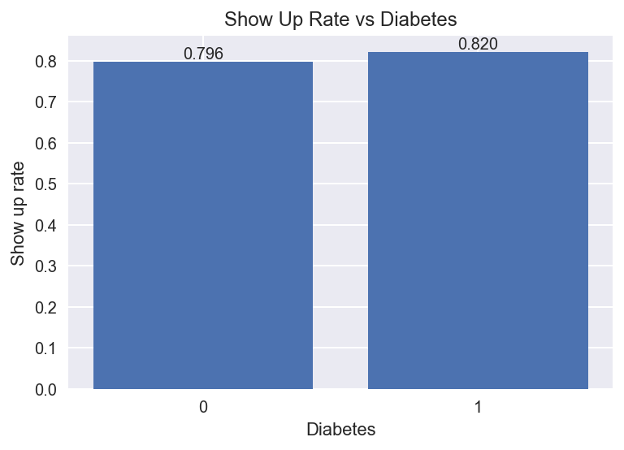

```python
# 获取数据
show_rate_by_diabetes = show_rate_by_feature('diabetes')
fig_data = show_rate_by_diabetes['fig_data']

# 画柱状图
plt.bar(x=fig_data.index, height=fig_data)
plt.title('Show Up Rate vs Diabetes')
plt.xlabel('Diabetes')
plt.xticks(range(0,2))
plt.ylabel('Show up rate')

# 添加数值大小,保留两位小数
for x,y in fig_data.items():
    plt.text(x, y, '%.3f'%y, ha='center', va= 'bottom')

plt.show()
```

糖尿病病人比非糖尿病病人的就诊率高出2.4%。

### 3.8 残障等级

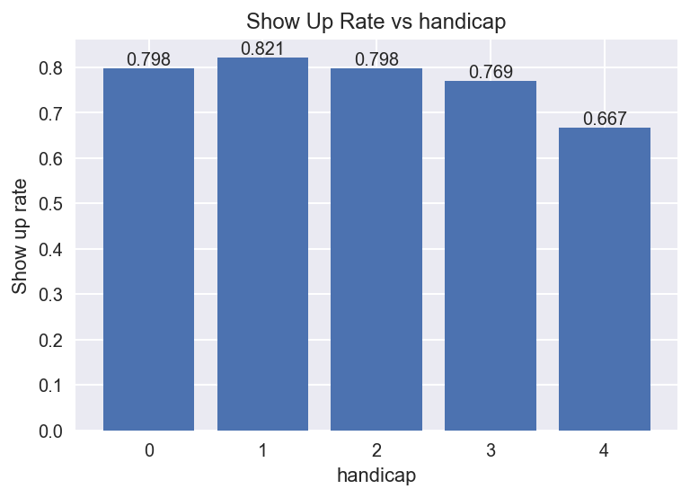

```
handicap  no_show
0         No         86373
          Yes        21912
1         No          1676
          Yes          366
2         No           146
          Yes           37
3         No            10
          Yes            3
4         No             2
          Yes            1
Name: patient_id, dtype: int64
```

```python
# 获取数据
show_rate_by_handicap = show_rate_by_feature('handicap')
fig_data = show_rate_by_handicap['fig_data']

# 画柱状图
plt.bar(x=fig_data.index, height=fig_data)
plt.title('Show Up Rate vs handicap')
plt.xlabel('handicap')
plt.xticks(range(0,5))
plt.ylabel('Show up rate')

# 添加数值大小,保留两位小数
for x,y in fig_data.items():
    plt.text(x, y, '%.3f'%y, ha='center', va= 'bottom')

plt.show()

show_rate_by_handicap['raw_data']
```

残障等级3和4数据量过小，不足以说明问题，残障等级为1的病人比残障等级为0或者2的病人的就诊率高出2.3%。

### 3.9 性别

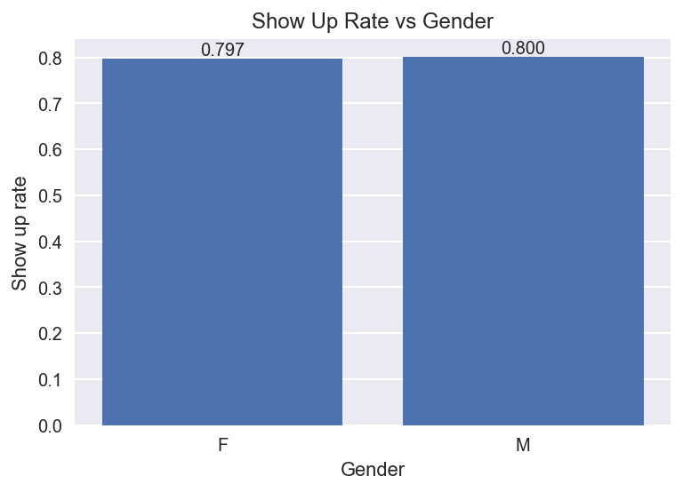

```python
# 获取数据
show_rate_by_gender = show_rate_by_feature('gender')
fig_data = show_rate_by_gender['fig_data']

# 画柱状图
plt.bar(x=fig_data.index, height=fig_data)
plt.title('Show Up Rate vs Gender')
plt.xlabel('Gender')
plt.ylabel('Show up rate')

# 添加数值大小,保留两位小数
for x,y in fig_data.items():
    plt.text(x, y, '%.3f'%y, ha='center', va= 'bottom')

plt.show()
```

不同性别的就诊率几乎相同，说明性别对是否如约就诊没有影响。

### 3.10 是否酗酒

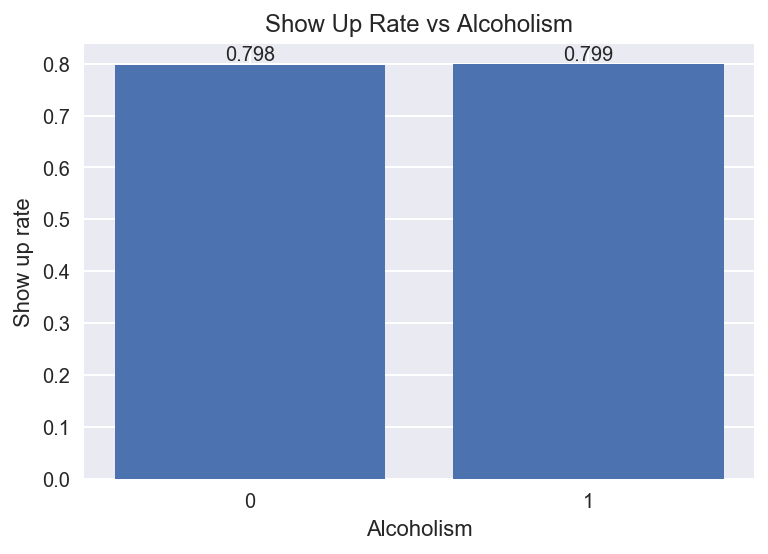

```python
# 获取数据
show_rate_by_alcoholism = show_rate_by_feature('alcoholism')
fig_data = show_rate_by_alcoholism['fig_data']

# 画柱状图
plt.bar(x=fig_data.index, height=fig_data)
plt.title('Show Up Rate vs Alcoholism')
plt.xlabel('Alcoholism')
plt.xticks(range(0,2))
plt.ylabel('Show up rate')

# 添加数值大小,保留两位小数
for x,y in fig_data.items():
    plt.text(x, y, '%.3f'%y, ha='center', va= 'bottom')

plt.show()
```

病人是否酗酒，就诊率几乎相同，所以该特征对是否就诊没有影响。

## 四. 结论

通过以上探索性分析可知：

- 病人的预约集中在工作日，周一到周三每天的预约数量多于周四，周五的预约
- 年龄上来看，病人的预约集中在0到60岁年龄段
- 性别上来看，病人的预约集中为女性，是男性预约的2倍
- 病人能否按照预约前往就诊与性别，是否酗酒无关；与是否有短信提醒，是否享受福利保障，是否患高血压，星期几就诊，年龄大小，医院地点（街区），是否患糖尿病，残障等级有关，其中是否收到短信影响最为显著，是否享受福利保障次之，其余特征影响力皆较弱。

完成本项目所参考的网站：

- [Kaggle](https://www.kaggle.com/joniarroba/noshowappointments)
- [Matplotlib Bar chart](http://pythonspot.com/en/matplotlib-bar-chart/)
- [Html Color](https://htmlcolorcodes.com/color-names/)